# omicsPrint: detection of data linkage errors in multiple omics studies

Maarten van Iterson

Department of Medical Statistics and Bioinformatics, Section Moleculair Epidemiology, Leiden University Medical Center, Leiden, The Netherlands  
mviterson@gmail.com

Davy Cats

Department of Medical Statistics and Bioinformatics, Section Moleculair Epidemiology, Leiden University Medical Center, Leiden, The Netherlands  
davycats.dc@gmail.com

Paul Hop

Department of Medical Statistics and Bioinformatics, Section Moleculair Epidemiology, Leiden University Medical Center, Leiden, The Netherlands  
pjhop@gmail.com

Bas T. Heijmans

Department of Medical Statistics and Bioinformatics, Section Moleculair Epidemiology, Leiden University Medical Center, Leiden, The Netherlands  
b.t.heijmans@lumc.nl

2026-06-22

Abstract

The Aanalysis of multiple omics datatypes from the same individuals is becoming increasingly common. For example, several data repositories contain genetic, transcriptomic and epigenetic (DNA methylation) measurements on the same individuals, e.g., TCGA, Geuvadis, BBMRI/BIOS, etc. However, errors in the data linkage are almost inevitable in such complex projects (e.g. due to sample mix-ups) and unknown family relationships may be present. If not corrected, such errors may introduce false positive or false negative findings. To streamline necessary quality control, wWe have developed a tool to reliably verify the sample relationships between and across omics data types using genotype data that is directly measured or inferred from for example RNA-seq or DNA methylation array data.

# Within omics sample relationship verification

Here we illustrate how to detect data linkage errors with the *omicsPrint* package using both artificially generated data and experimental data. Several additional vignettes are available that show the use of the package on further experimental data in different settings, i.e., 450k DNA methylation and imputed genotypes.

## Create toy data

Here we generate a single vector with 100 randomly drawn integers from the set; 1, 2, 3, representing 100 SNP calls from a single individual. Three additional individuals are generated by randomly swapping a certain fraction of the SNPs. Swapping 5 SNPs will introduce a few mismatches mimicking a situation where the same individual was measured twice (replicate) but with measurement error. Swapping 50% of the SNPs will be similar to the difference in genotypes between parents and offspring. Swapping all SNPs will result in a situation similar to comparing two unrelated individuals.

```r
swap <- function(x, frac=0.05) {
    n <- length(x)
    k <- floor(n*frac)
    x1 <- sample(1:n,k)
    x2 <- sample(1:n,k) ##could be overlapping
    x[x2] <- x[x1]
    x
}
x1 <- 1 + rbinom(100, size=2, prob=1/3)
x2 <- swap(x1, 0.05) ##strongly related e.g. replicate
x3 <- swap(x1, 0.5) ##related e.g. parent off spring
x4 <- swap(x1, 1) ##unrelated
x <- cbind(x1, x2, x3, x4)
```

Now `x` contains the 100 SNPs for the four individuals using `head` we can inspect the first six SNPs.

```r
head(x)
```

```
##      x1 x2 x3 x4
## [1,]  1  1  2  2
## [2,]  2  2  2  1
## [3,]  1  1  3  1
## [4,]  1  1  2  1
## [5,]  1  1  2  2
## [6,]  2  2  2  2
```

## Running the `allelesharing` algorithm

We use Identity by State (IBS) for the set of SNPs to infer sample relations. See Abecasis et al. (2001), for the description of this approach applied to genetic data. Briefly, between each sample pair, the IBS-vector is calculated, which is a measure of genetic distance between individuals. Next, the vector is summarized by its mean and variance. A mean of 2 and variance of 0 indicates that the samples are identical.

```r
data <- alleleSharing(x, verbose=TRUE)
```

```
## Hash relations
```

```
## Pruning 100 SNPs ...
```

```
## 0 SNPs removed because of low call rate!
```

```
## 0 samples removed because too few SNPs called!
```

```
## Using 100 polymorphic SNPs to determine allele sharing.
```

```
## Running `square` IBS algorithm!
```

The set of SNPs may contain uninformative SNPs, SNPs of bad quality or even SNPs could be missing. The following pruning steps are implemented to yield the most informative set of SNPs (thresholds can be adjusted see `?alleleSharing`):

1. a SNP is remove if missing in >5% of the samples (`callRate = 0.95`)
2. a sample should have at least 2/3 of the SNPs called (`coverageRate = 2/3`)
3. a SNP is can be removed if it violates the Hardy-Weinberg equilibrium (`alpha = 0`).
4. a SNP is can be removed if the minor allele frequency is below the given threshold (`maf = 0`)

Hardy-Weinberg test-statistics is calculated using a $\chi^2$-test and Bonferonni multiple testing correction is performed.

```r
data
```

```
##    mean       var colnames.x colnames.y  relation
## 1  2.00 0.0000000         x1         x1 identical
## 2  1.96 0.0589899         x2         x1 unrelated
## 3  1.62 0.3187879         x3         x1 unrelated
## 4  1.40 0.3636364         x4         x1 unrelated
## 5  2.00 0.0000000         x2         x2 identical
## 6  1.60 0.3434343         x3         x2 unrelated
## 7  1.38 0.3793939         x4         x2 unrelated
## 8  2.00 0.0000000         x3         x3 identical
## 9  1.40 0.4242424         x4         x3 unrelated
## 10 2.00 0.0000000         x4         x4 identical
```

By default no relations are assumed except for the self-self relations.

The output is a `data.frame` containing all pairwise comparisons with the mean and variance of the IBS over the set of SNPs and the reported sample relationship, including the identifiers.

## Report mismatches and provide graphical summary

Since we provided a list of known relations and assume that the majority is correct, we can build a classifier to discover misclassified relations. Linear discriminant analysis is used to generate a confusion-matrix, which is subsequently used to graphically represent the classification boundaries and generate an output file with misclassified sample pairs.

```r
mismatches <- inferRelations(data)
```

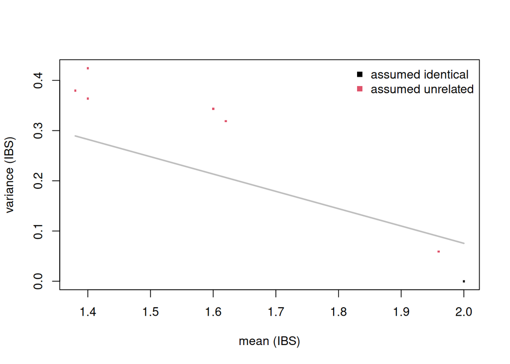

Scatter-plot of IBS mean and variance with classification boundary for pairwise comparison between the samples without specifying sample relationships using artificially generated data.

```r
mismatches
```

```
##   mean       var colnames.x colnames.y  relation predicted
## 2 1.96 0.0589899         x2         x1 unrelated identical
```

```r
relations <- expand.grid(idx = colnames(x), idy= colnames(x))
relations$relation_type <- "unrelated"
relations$relation_type[relations$idx == relations$idy] <- "identical"
relations$relation_type[c(2,5)] <- "identical" ##replicate
relations$relation_type[c(3,7,9,10)] <- "parent offspring"
relations
```

```
##    idx idy    relation_type
## 1   x1  x1        identical
## 2   x2  x1        identical
## 3   x3  x1 parent offspring
## 4   x4  x1        unrelated
## 5   x1  x2        identical
## 6   x2  x2        identical
## 7   x3  x2 parent offspring
## 8   x4  x2        unrelated
## 9   x1  x3 parent offspring
## 10  x2  x3 parent offspring
## 11  x3  x3        identical
## 12  x4  x3        unrelated
## 13  x1  x4        unrelated
## 14  x2  x4        unrelated
## 15  x3  x4        unrelated
## 16  x4  x4        identical
```

Rerun the allelesharing algorithm now provided with the known relations.

```r
data <- alleleSharing(x, relations=relations)
```

```
## Hash relations
```

```
## Pruning 100 SNPs ...
```

```
## 0 SNPs removed because of low call rate!
```

```
## 0 samples removed because too few SNPs called!
```

```
## Using 100 polymorphic SNPs to determine allele sharing.
```

```
## Running `square` IBS algorithm!
```

```r
data
```

```
##    mean       var colnames.x colnames.y         relation
## 1  2.00 0.0000000         x1         x1        identical
## 2  1.96 0.0589899         x2         x1        identical
## 3  1.62 0.3187879         x3         x1 parent offspring
## 4  1.40 0.3636364         x4         x1        unrelated
## 5  2.00 0.0000000         x2         x2        identical
## 6  1.60 0.3434343         x3         x2 parent offspring
## 7  1.38 0.3793939         x4         x2        unrelated
## 8  2.00 0.0000000         x3         x3        identical
## 9  1.40 0.4242424         x4         x3        unrelated
## 10 2.00 0.0000000         x4         x4        identical
```

```r
mismatches <- inferRelations(data)
```

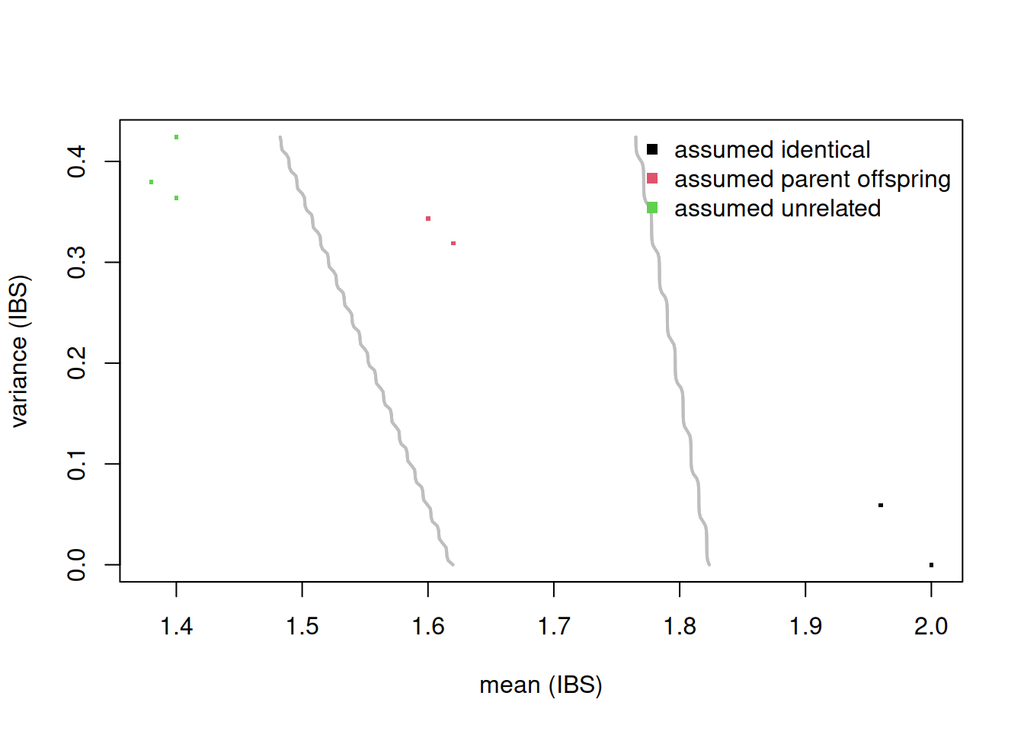

Scatter-plot of IBS mean and variance with classification boundaries for pairwise comparison between the samples with specifying sample relationships using artificially generated data.

```r
mismatches
```

```
## [1] mean       var        colnames.x colnames.y relation   predicted
## <0 rows> (or 0-length row.names)
```

All misclassified relations were resolved.

# Across omics data type sample relationship verification

The previous example showed how to perform sample relationship verification within a single omics data type. If a second set of SNPs is available obtained from a different omic data type (and the SNPs are partly overlapping), *omicsPrint* can be used to verify relationships between omics types, e.g. to establish whether two omics data types were indeed generated for the same individual in order to exclude or detect sample mix-ups.

In this artificial example a random subset of 80 SNPs is selected as the set of SNPs from a different omic type. First running without providing the known relations.

```r
rownames(x) <- paste0("rs", 1:100)
y <- x[sample(1:100, 80),]
data <- alleleSharing(x, y)
```

```
## Hash relations
```

```
## Pruning 100 SNPs ...
```

```
## 0 SNPs removed because of low call rate!
```

```
## 0 samples removed because too few SNPs called!
```

```
## Pruning 80 SNPs ...
```

```
## 0 SNPs removed because of low call rate!
```

```
## 0 samples removed because too few SNPs called!
```

```
## Using 80 polymophic SNPs to determine allele sharing.
```

```
## Running `rectangular` IBS algorithm!
```

Note that pruning is performed on both data types and automatically a set of overlapping SNPs (80) is used provided that the rownames of `x` and `y` are identical (this also holds for sample relations where the relation identifiers `idx` and `idy` should match with the columnames of `x` and `y`).

```r
data
```

```
##     mean        var colnames.x colnames.y  relation
## 1  2.000 0.00000000         x1         x1 identical
## 2  1.950 0.07341772         x2         x1 unrelated
## 3  1.625 0.31329114         x3         x1 unrelated
## 4  1.425 0.34873418         x4         x1 unrelated
## 5  1.950 0.07341772         x1         x2 unrelated
## 6  2.000 0.00000000         x2         x2 identical
## 7  1.600 0.34430380         x3         x2 unrelated
## 8  1.400 0.36962025         x4         x2 unrelated
## 9  1.625 0.31329114         x1         x3 unrelated
## 10 1.600 0.34430380         x2         x3 unrelated
## 11 2.000 0.00000000         x3         x3 identical
## 12 1.375 0.41455696         x4         x3 unrelated
## 13 1.425 0.34873418         x1         x4 unrelated
## 14 1.400 0.36962025         x2         x4 unrelated
## 15 1.375 0.41455696         x3         x4 unrelated
## 16 2.000 0.00000000         x4         x4 identical
```

```r
mismatches <- inferRelations(data)
```

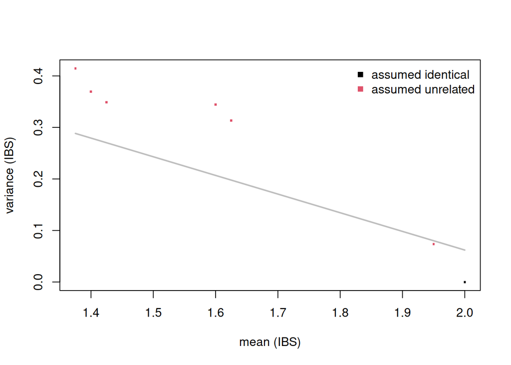

Scatter-plot of IBS mean and variance with classification boundary for pairwise comparison between the samples without specifying sample relationships using artificial data.

```r
mismatches
```

```
##   mean        var colnames.x colnames.y  relation predicted
## 2 1.95 0.07341772         x2         x1 unrelated identical
## 5 1.95 0.07341772         x1         x2 unrelated identical
```

Now running with providing the known relations.

```r
data <- alleleSharing(x, y, relations)
```

```
## Hash relations
```

```
## Pruning 100 SNPs ...
```

```
## 0 SNPs removed because of low call rate!
```

```
## 0 samples removed because too few SNPs called!
```

```
## Pruning 80 SNPs ...
```

```
## 0 SNPs removed because of low call rate!
```

```
## 0 samples removed because too few SNPs called!
```

```
## Using 80 polymophic SNPs to determine allele sharing.
```

```
## Running `rectangular` IBS algorithm!
```

```r
data
```

```
##     mean        var colnames.x colnames.y         relation
## 1  2.000 0.00000000         x1         x1        identical
## 2  1.950 0.07341772         x2         x1        identical
## 3  1.625 0.31329114         x3         x1 parent offspring
## 4  1.425 0.34873418         x4         x1        unrelated
## 5  1.950 0.07341772         x1         x2        identical
## 6  2.000 0.00000000         x2         x2        identical
## 7  1.600 0.34430380         x3         x2 parent offspring
## 8  1.400 0.36962025         x4         x2        unrelated
## 9  1.625 0.31329114         x1         x3 parent offspring
## 10 1.600 0.34430380         x2         x3 parent offspring
## 11 2.000 0.00000000         x3         x3        identical
## 12 1.375 0.41455696         x4         x3        unrelated
## 13 1.425 0.34873418         x1         x4        unrelated
## 14 1.400 0.36962025         x2         x4        unrelated
## 15 1.375 0.41455696         x3         x4        unrelated
## 16 2.000 0.00000000         x4         x4        identical
```

```r
mismatches <- inferRelations(data)
```

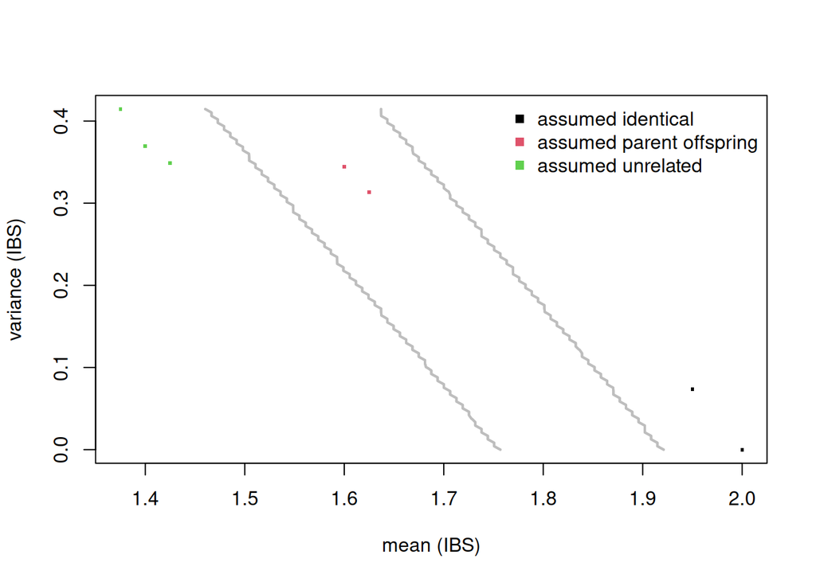

Scatter-plot of IBS mean and variance with classification boundaries for pairwise comparison between the samples with specifying sample relationships using artificial data.

```r
mismatches
```

```
## [1] mean       var        colnames.x colnames.y relation   predicted
## <0 rows> (or 0-length row.names)
```

Providing the known, true relationships thus yields no missclassified sample relationships.

# An example using real world methylation data from a `SummarizedExperiment`

Here we will show how you could varify sample relationships on publicly available DNA methylation data. The dataset used here contains pairs of monozygotic twins. We will extract the beta-value matrix from GEO GSE100940, [paper in press](http://www.sciencedirect.com/science/article/pii/S1875176817300872).

First we extract the data from GEO using the [*GEOquery*](http://bioconductor.org/packages/GEOquery/)-package.

```r
library(GEOquery)
library(SummarizedExperiment)
file <- tempfile(fileext = ".txt.gz")
download.file("ftp://ftp.ncbi.nlm.nih.gov/geo/series/GSE100nnn/GSE100940/matrix/GSE100940_series_matrix.txt.gz", file)
gset <- getGEO(filename=file, getGPL=FALSE)
```

Dependending on your version of `GEOquery`, `getGEO` might already return a `SummarizedExperiment` object. If not, then following code can be used to convert it into a [*SummarizedExperiment*](http://bioconductor.org/packages/SummarizedExperiment/):

```r
se <- makeSummarizedExperimentFromExpressionSet(gset)
se
```

Sample data can be extracted from the `SummarizedExperiment`-object using the `colData`-function and we can see which pair of twins each sample belongs to through the `source_name_ch1` field. Using this knowledge we can construct a table of expected relationships:

```r
r <- expand.grid(idx=colnames(se), idy=colnames(se))
r$Xpair <- sapply(strsplit(as.character(colData(se)[r$idx, "source_name_ch1"]),
                           split = "_"), head, 1)
r$Ypair <- sapply(strsplit(as.character(colData(se)[r$idy, "source_name_ch1"]),
                           split = "_"), head, 1)
r$relation_type <- "unrelated"
r$relation_type[r$Xpair == r$Ypair] <- "twin"
r$relation_type[r$idx == r$idy] <- "identical"
head(r)
```

```
##          idx        idy Xpair Ypair relation_type
## 1 GSM2696882 GSM2696882   M01   M01     identical
## 2 GSM2696883 GSM2696882   M01   M01          twin
## 3 GSM2696884 GSM2696882   M02   M01     unrelated
## 4 GSM2696885 GSM2696882   M02   M01     unrelated
## 5 GSM2696886 GSM2696882   M03   M01     unrelated
## 6 GSM2696887 GSM2696882   M03   M01     unrelated
```

Several probes on the array contain SNPs occurring frequently in different populations(Chen et al. 2013; Zhou et al. 2016). We can use these to verify the expected relationships. We have made these data available from inside of this package.

Now we make a selection of CpGs probably affected by polymorphic SNPS in populations from East Asian, as these samples are from South Korea:

```r
data(hm450.manifest.pop.GoNL)
cpgs <- names(hm450.manifest.pop.GoNL[
    mcols(hm450.manifest.pop.GoNL)$MASK.snp5.EAS])
se <- se[cpgs,]
```

Next the beta-values are converted to genotypes using our enhanced K-means algorithm:

```r
dnamCalls <- beta2genotype(se, assayName = "exprs")
dim(dnamCalls)
```

```
## [1] 821  24
```

```r
dnamCalls[1:5, 1:5]
```

```
##            GSM2696882 GSM2696883 GSM2696884 GSM2696885 GSM2696886
## cg09762182          3          3          1          1          3
## cg25282454          3          3          2          2          2
## cg24345856          3          3          2          2          2
## cg13167158          3          3          3          3          1
## cg12213037          2          2          3          3          3
```

The DNA methylation based genotype calls can be directly supplied to the allelesharing algorithm to perform the intra-omic sample matching:

```r
data <- alleleSharing(dnamCalls, relations = r, verbose = TRUE)
```

```
## Hash relations
```

```
## Pruning 821 SNPs ...
```

```
## 0 SNPs removed because of low call rate!
```

```
## 0 samples removed because too few SNPs called!
```

```
## Using 821 polymorphic SNPs to determine allele sharing.
```

```
## Running `square` IBS algorithm!
```

```
## 25 of 300 (8.33%) ...
```

```r
mismatches <- inferRelations(data)
```

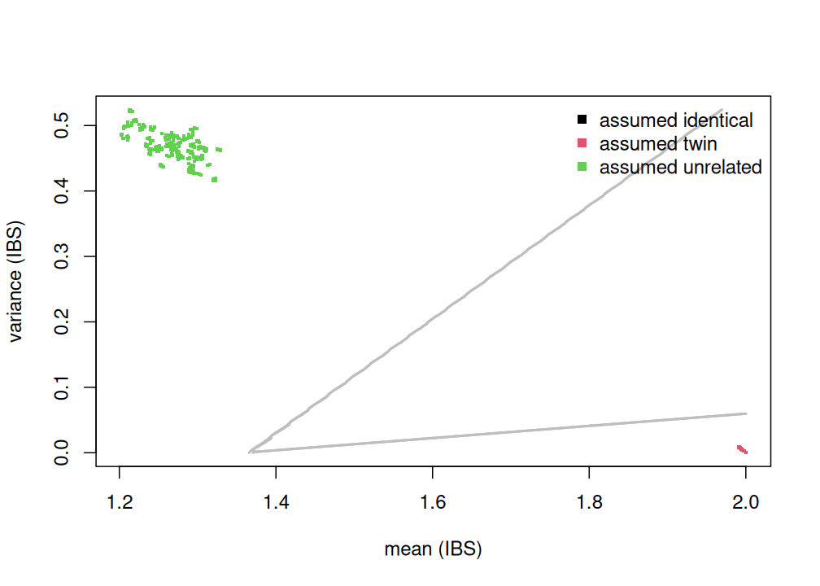

Scatter-plot of IBS mean and variance with classification boundaries for pairwise comparison between samples consisting of pairs of monozygotic twins.

```r
mismatches
```

```
##         mean         var colnames.x colnames.y relation predicted
## 2   1.995128 0.004854282 GSM2696883 GSM2696882     twin identical
## 49  1.997564 0.002433083 GSM2696885 GSM2696884     twin identical
## 92  1.991474 0.008463801 GSM2696887 GSM2696886     twin identical
## 131 1.995128 0.004854282 GSM2696889 GSM2696888     twin identical
## 166 1.995128 0.004854282 GSM2696891 GSM2696890     twin identical
## 197 1.995128 0.004854282 GSM2696893 GSM2696892     twin identical
## 224 1.996346 0.003645168 GSM2696895 GSM2696894     twin identical
## 247 2.000000 0.000000000 GSM2696897 GSM2696896     twin identical
## 266 1.995128 0.004854282 GSM2696899 GSM2696898     twin identical
## 281 1.992692 0.007263599 GSM2696901 GSM2696900     twin identical
## 292 1.993910 0.006060426 GSM2696903 GSM2696902     twin identical
## 299 1.993910 0.006060426 GSM2696905 GSM2696904     twin identical
```

The twins are predicted as being identical to each other. This is not unexpected as they are monozygotic.

# Reference

Abecasis, G. R., S. S. Cherny, W. O. Cookson, and L. R. Cardon. 2001. “GRR: graphical representation of relationship errors.” *Bioinformatics* 17 (8): 742–43.

Chen, Y. A., M. Lemire, S. Choufani, et al. 2013. “Discovery of cross-reactive probes and polymorphic CpGs in the Illumina Infinium HumanMethylation450 microarray.” *Epigenetics* 8 (2): 203–9.

Zhou, W., P. W. Laird, and H. Shen. 2016. “Comprehensive characterization, annotation and innovative use of Infinium DNA methylation BeadChip probes.” *Nucleic Acids Res.*, October.